# Ecoli-Human Spike-in Study (PRIDE ID PXD003881): Hurdle analysis

Lieven Clement

26 May 2020

# 1 Background

```r
concentrations <- seq.int(1:5) * 1.5
names(concentrations) <- letters[1:5]
```

# 2 Data

We first import the peptides.txt file. This is the file that contains your peptide-level intensities. For a MaxQuant search [6], this peptides.txt file can be found by default in the “path_to_raw_files/combined/txt/” folder from the MaxQuant output, with “path_to_raw_files” the folder where raw files were saved. In this tutorial, we will use a MaxQuant peptides file of the ecoli spike-in study that is stored in the msdata package. We use the Features package to import the data.

With the grepEcols function we find the columns that are containing the expression data of the peptides in the peptides.txt file.

```r
library(tidyverse)
library(limma)
library(Features)
library(msqrob2)

myurl<- "https://www.dropbox.com/s/62hhol96pz0sjbi/peptides.zip?dl=0"
download.file(myurl, "peptides.zip", method = "curl", extra = "-L")
unzip("peptides.zip")
peptidesFile <- "peptides.txt"
ecols <- MSnbase::grepEcols(peptidesFile, "Intensity ", split = "\t")
pe <- readFeatures(table = peptidesFile, fnames = 1, ecol = ecols,
                   name = "peptideRaw", sep = "\t")
pe
```

```
## A instance of class Features containing
##  [1] peptideRaw: SummarizedExperiment with 32827 rows and 20 columns
```

We can extract the spikein condition from the raw file name.

```r
cond <- which(strsplit(colnames(pe)[[1]][1], split = "")[[1]] == "a") # find where condition is stored
colData(pe)$condition <- substr(colnames(pe), cond, cond) %>% unlist %>%  as.factor
```

We calculate how many non zero intensities we have per peptide. This will be useful for filtering.

```r
rowData(pe[["peptideRaw"]])$nNonZero <- rowSums(assay(pe[["peptideRaw"]]) > 0)
```

Peptides with zero intensities are missing peptides and should be represent with a `NA` value instead of `0`.

```r
pe <- zeroIsNA(pe, i = "peptideRaw")
```

## 2.1 Information on species

In the spikin-study there are peptides from ecoli and human proteins. The ecoli peptides are spiked.

```r
myurl<- "https://www.dropbox.com/s/swhu9nqwktythtb/ecoli_up000000625_7_06_2018.fasta?dl=0"
download.file(myurl, "ecoli.fasta", method="curl", extra="-L")
myurl<-"https://www.dropbox.com/s/n61n28wrcpwsb4a/human_up000005640_sp_7_06_2018.fasta?dl=0"
download.file(myurl, "human.fasta", method="curl", extra="-L")
```

```r
id <- list(ecoli = 'ecoli.fasta',
          human = 'human.fasta') %>%
  map(~{read_lines(.x) %>%
          {.[str_detect(.,'^>')]} %>%
          str_extract(.,'(?<=\\|).*(?=\\|)')})
```

## 2.2 Data exploration

We can inspect the missingness in our data with the `plotNA()` function provided with `MSnbase`. 23% of all peptide intensities are missing and for some peptides we do not even measure a signal in any sample. The missingness is similar across samples.

```r
MSnbase::plotNA(assay(pe)) +
  xlab("Peptide index (ordered by data completeness)")
```

[output not shown]

# 3 Preprocessing

We normalize the data using vsn normalisation. Note, that the data should not be log-transformed then.

## 3.1 Filtering

### 3.1.1 Handling overlapping protein groups

In our approach a peptide can map to multiple proteins, as long as there is none of these proteins present in a smaller subgroup.

```r
pe[["peptideRaw"]]<-pe[["peptideRaw"]][rowData(pe[["peptideRaw"]])$Proteins %in% smallestUniqueGroups(rowData(pe[["peptideRaw"]])$Proteins),]
```

### 3.1.2 Remove reverse sequences (decoys) and contaminants

We now remove the contaminants, peptides that map to decoy sequences and proteins, which were only identified by peptides with modifications.

```r
pe[["peptideRaw"]] <- pe[["peptideRaw"]][rowData(pe[["peptideRaw"]])$Reverse!= "+", ]
pe[["peptideRaw"]] <- pe[["peptideRaw"]][rowData(pe[["peptideRaw"]])$
Potential.contaminant!="+", ]
```

### 3.1.3 Drop peptides that were only identified in one sample

We want to keep peptide that were at least observed twice.

```r
pe[["peptideRaw"]] <- pe[["peptideRaw"]][rowData(pe[["peptideRaw"]])$nNonZero >= 2, ]
nrow(pe[["peptideRaw"]])
```

```
## [1] 28944
```

We keep 28944 peptides upon filtering.

## 3.2 Normalize the data using the `vsn` method

```r
pe <- normalize(pe, i = "peptideRaw", method = "vsn", name = "peptideNorm")
```

Upon normalisation the density curves for all samples coincide.

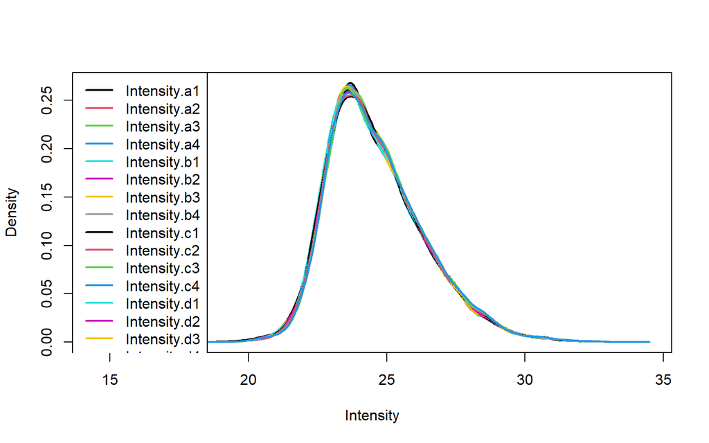

```r
limma::plotDensities(assay(pe[["peptideNorm"]]))
```

We can visualize our data using a multi-dimensional scaling plot, eg. as provided by the limma package.

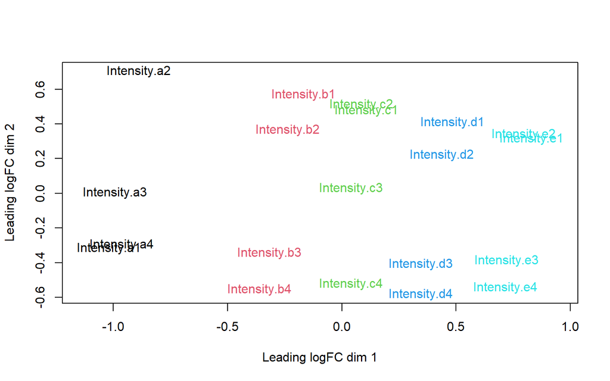

```r
limma::plotMDS(assay(pe[["peptideNorm"]]), col = as.numeric(colData(pe)$condition))
```

The first axis in the plot is showing the leading log fold changes (differences on the log scale) between the samples. We notice that the leading differences (log FC) in the peptide data seems to be driven by the spike-in condition.

## 3.4 Summarization to protein level

### 3.4.1 Intensity based

Use the standard summarisation in aggregateFeatures (robust summarisation).

```r
pe <- aggregateFeatures(pe, i = "peptideNorm", fcol = "Proteins", na.rm = TRUE, name = "protein")
```

```
## Your quantitative and row data contain missing values. Please read the
## relevant section(s) in the aggregateFeatures manual page regarding the
## effects of missing values on data aggregation.
```

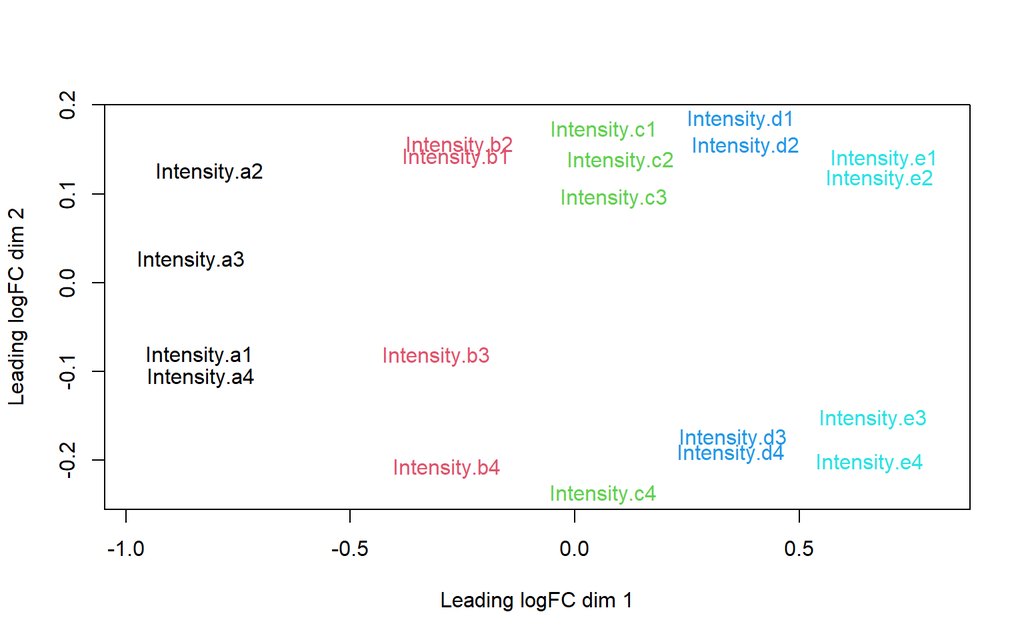

```r
plotMDS(assay(pe[["protein"]]),col = as.numeric(colData(pe)$condition))
```

### 3.4.2 Count based

We make and additional summarisation assay where we summarise the peptides to protein values by counting how many peptides are observed for each protein.

We also need to create a column in the rowData of the assay with the number of peptides that could be observed per protein, which we call nPep.

```r
pe <- aggregateFeatures(pe, i = "peptideNorm", fcol = "Proteins", name = "proteinCount", fun = nObsPep)
```

```
## Your quantitative and row data contain missing values. Please read the
## relevant section(s) in the aggregateFeatures manual page regarding the
## effects of missing values on data aggregation.
```

```r
rowData(pe[["proteinCount"]])$nPep<- rowData(pe[["peptideNorm"]]) %>%
        data.frame(.$Proteins)  %>%
        group_by(Proteins) %>%
        summarise(nPep = length(Proteins)) %>%
        column_to_rownames("Proteins") %>%
        .$nPep
```

# 4 Data Analysis

## 4.1 Estimation intensity based method

We model the protein level expression values using msqrob. By default msqrob2 estimates the model parameters using robust regression.

```r
pe <- msqrob(object = pe, i = "protein", formula = ~condition)
```

## 4.2 Estimation count based method

```r
pe <- msqrobQB(object = pe, i = "proteinCount", formula = ~condition)
```

[output not shown]

[output cut: 9364 more lines]

[output not shown]

## 4.3 Inference

What are the parameter names of the model?

```r
getCoef(rowData(pe[["protein"]])$msqrobModels[[1]])
```

```
## (Intercept)  conditionb  conditionc  conditiond  conditione
## 23.44881438  0.08851106  0.03863228  0.01051063 -0.07124313
```

Spike-in condition a is the reference class. So the mean log2 expression for samples from condition a is ‘(Intercept). The mean log2 expression for samples from condition b-e is’(Intercept)+conditionb’,…,‘(Intercept)+conditione’, respectively. Hence, the average log2 fold change (FC) between condition b and condition a is modelled using the parameter ‘conditionb’. Thus, we assess the contrast ‘conditionb = 0’ with our statistical test. The same holds for comparison c-a, d-a, e-a.

```r
comparisonsRef <- paste0(paste0("condition", letters[2:5]), " = 0")
comparisonsRef
```

```
## [1] "conditionb = 0" "conditionc = 0" "conditiond = 0" "conditione = 0"
```

The test for average log2 FC between condition c and b will assess the contrast ‘conditionc - conditionb = 0’, …

```r
comparisonsOther <- paste0(
    apply(
          combn(paste0("condition", letters[2:5]), 2)[2:1, ],
          2,
          paste,
          collapse = " - ")
          ," = 0")
comparisonsOther
```

```
## [1] "conditionc - conditionb = 0" "conditiond - conditionb = 0"
## [3] "conditione - conditionb = 0" "conditiond - conditionc = 0"
## [5] "conditione - conditionc = 0" "conditione - conditiond = 0"
```

```r
comparisons <- c(comparisonsRef, comparisonsOther)
```

We make the contrast matrix using the makeContrast function

```r
L <- makeContrast(comparisons, parameterNames = paste0("condition", letters[2:5]))
L
```

```
##            conditionb conditionc conditiond conditione conditionc - conditionb
## conditionb          1          0          0          0                      -1
## conditionc          0          1          0          0                       1
## conditiond          0          0          1          0                       0
## conditione          0          0          0          1                       0
##            conditiond - conditionb conditione - conditionb
## conditionb                      -1                      -1
## conditionc                       0                       0
## conditiond                       1                       0
## conditione                       0                       1
##            conditiond - conditionc conditione - conditionc
## conditionb                       0                       0
## conditionc                      -1                      -1
## conditiond                       1                       0
## conditione                       0                       1
##            conditione - conditiond
## conditionb                       0
## conditionc                       0
## conditiond                      -1
## conditione                       1
```

And we adopt the hypothesis tests for each contrast and for both hurdle components.

```r
pe <- hypothesisTest(object = pe, i = "protein", contrast = L)
pe <- hypothesisTest(object = pe, i = "proteinCount", contrast = L)
for (j in colnames(L)) {
  sam <- cbind(rowData(pe[["protein"]])[[j]][,1:5],
               rowData(pe[["proteinCount"]])[[j]][,1:5])
  colnames(sam)[2:5] <- paste0("logFC", colnames(sam)[2:5])
  colnames(sam)[6] <- "logOR"
  colnames(sam)[7:10] <- paste0("logOR", colnames(sam)[7:10])
  sam$fisher <- -2*(log(sam[, 5]) + log(sam[, 10]))
  sam$fisherDf <- 4
  sam$fisherDf[is.na(sam$fisher)] <- 2
  id1 <- is.na(sam$fisher)&!is.na(sam[, 5])
  id2 <- is.na(sam$fisher)&!is.na(sam[, 10])
  sam$fisher[id1] <- -2 * log(sam[id1, 5])
  sam$fisher[id2] <- -2 * log(sam[id2, 10])
  sam$fisherPval <- pchisq(sam$fisher, sam$fisherDf, lower.tail = FALSE)
  sam$fisherAdjPval <- p.adjust(sam$fisherPval, "BH")
  rowData(pe[["proteinCount"]])[[paste0("hurdle", j)]] <- sam
}
```

# 5 Plots

## 5.1 Heatmaps

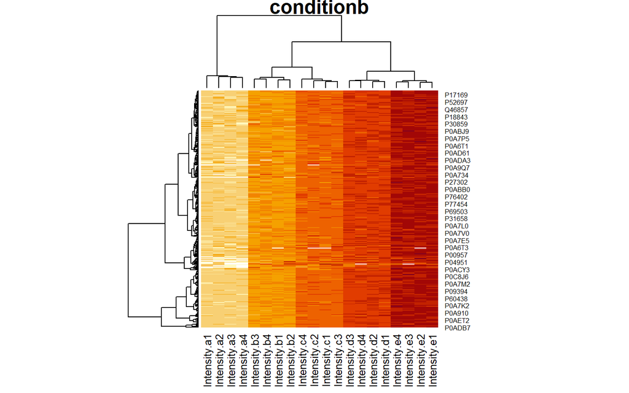

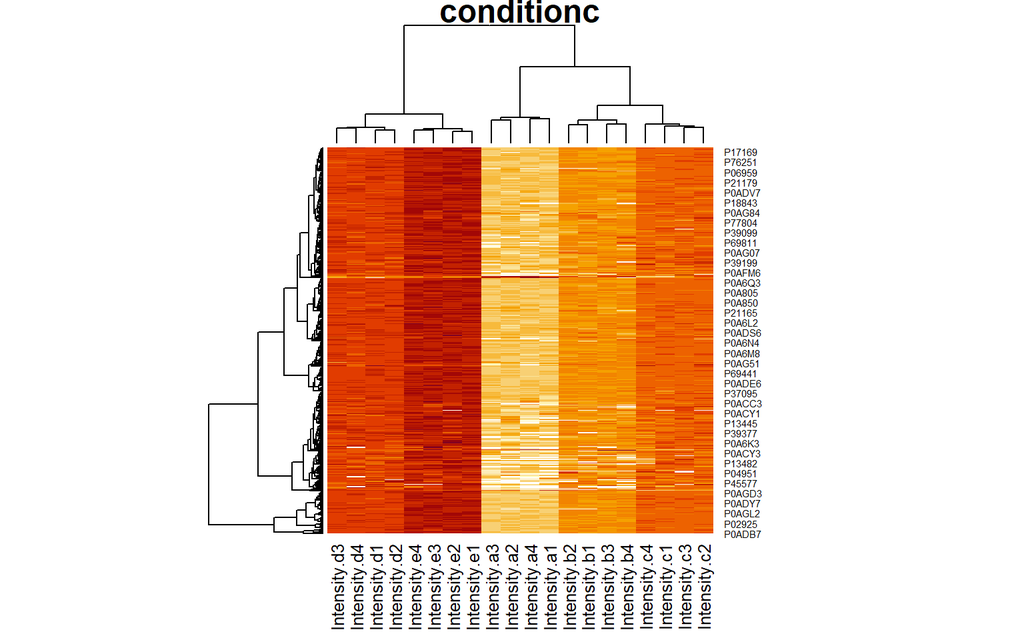

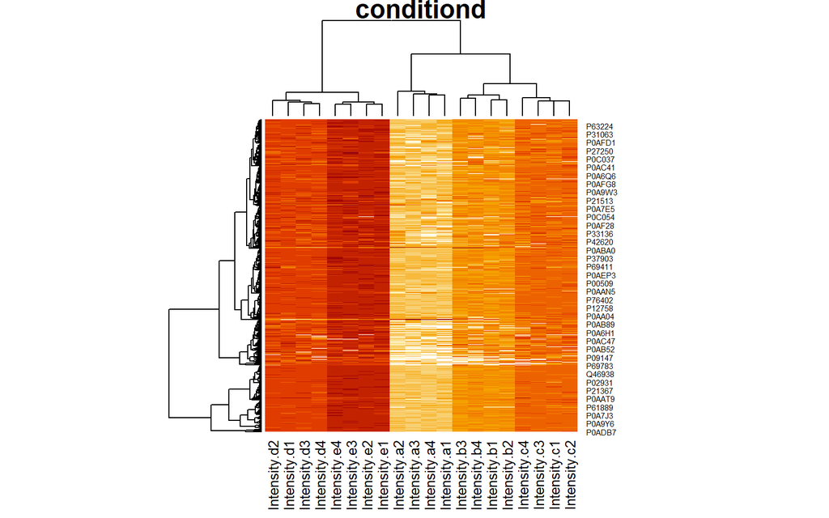

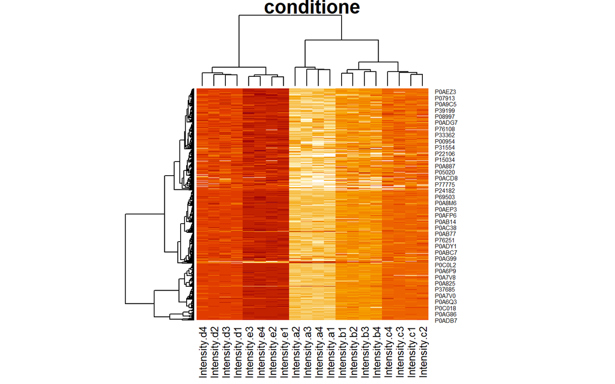

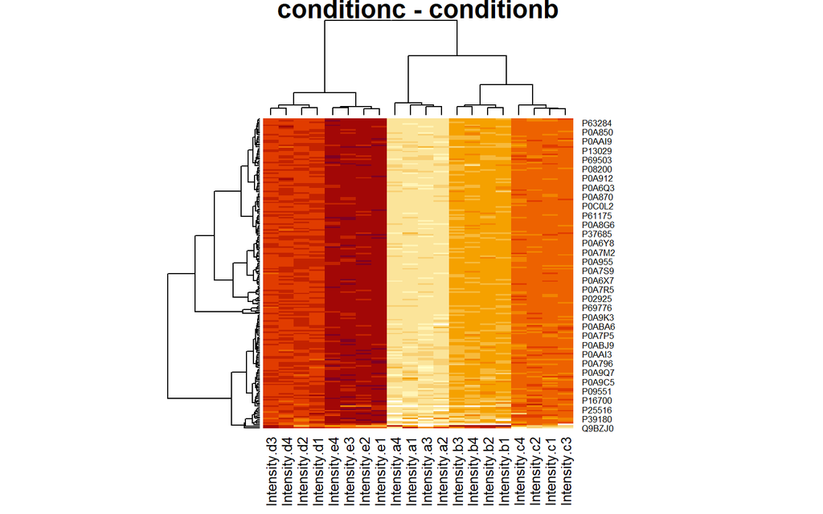

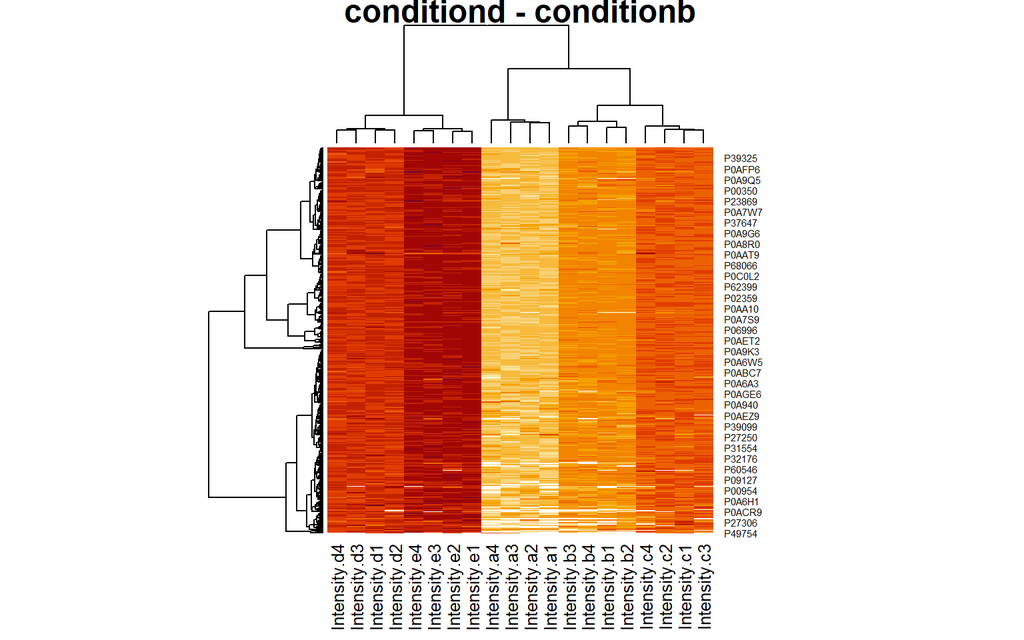

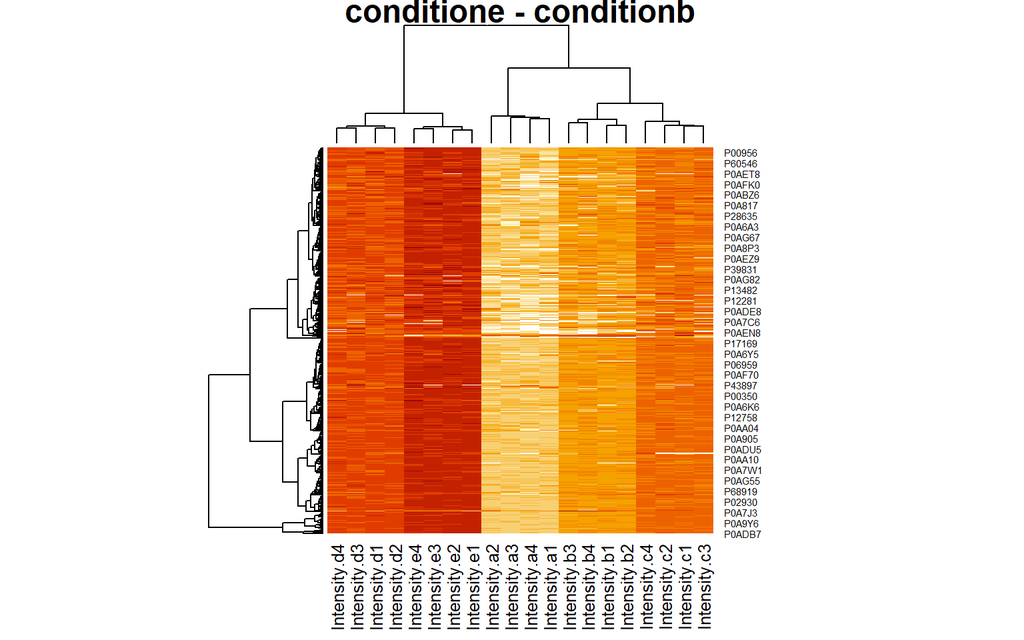

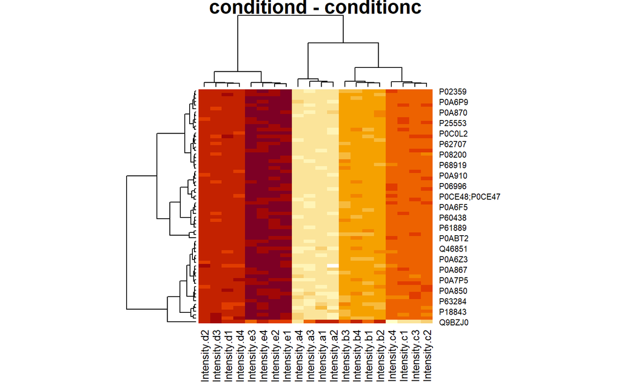

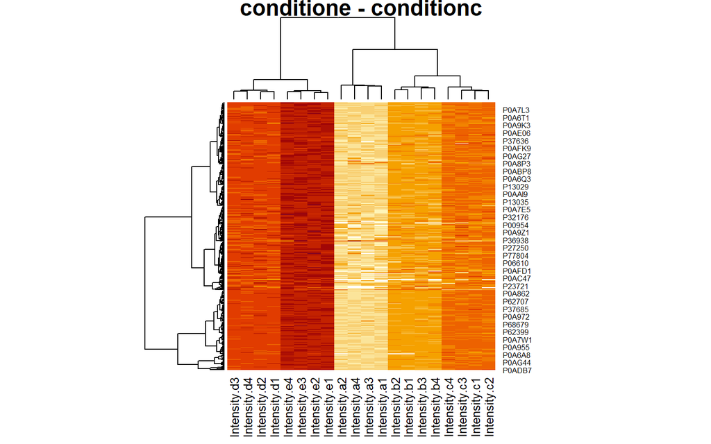

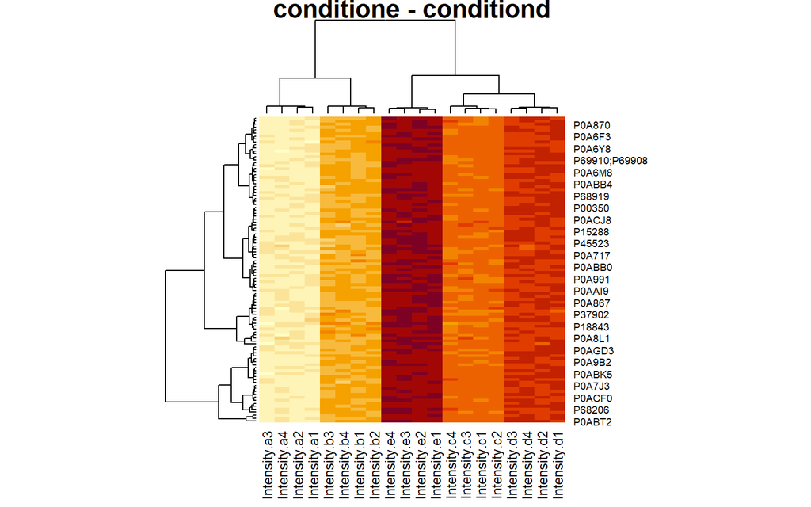

```r
for (i in colnames(L)) {
sigNames <- rowData(pe[["proteinCount"]])[[paste0("hurdle", i)]] %>%
    rownames_to_column("protein") %>% filter(fisherAdjPval<0.01) %>% pull(protein)
heatmap(assay(pe[["protein"]])[sigNames, ] , main=i)
}
```

## 5.2 Sensitivity FDP plots

Because we are analysing a spike-in study we know the ground truth, i.e. we know that only the spike-in proteins (ecoli) are differentially expressed. We can therefore evaluate the performance of the method, i.e. we will assess

- the sensitivity or true positive rate (TPR), the proportion of actual positives that are correctly identified, in the protein list that we return
  $$TPR=\frac{TP}{\text{#actual positives}},$$
  here TP are the true positives in the list. The TPR is thus the fraction of ups proteins that we can recall.
- false discovery proportion (FPD): fraction of false positives in the protein list that we return:
  $$FPD=\frac{FP}{FP+TP},$$
  with FP the false positives. In our case the yeast proteins that are in our list.

Instead of only calculating that for the protein list that is returned for the chosen FDR level, we can do this for all possible FDR cutoffs so that we get an overview of the quality of the ranking of the proteins in the protein list.

We first add the ground truth data to the rowData of the object.

```r
accessions <- rownames(pe[["protein"]]) %>%
    data_frame(protein = .)
accessions <- accessions %>%
    transmute(protein = as.character(protein), proteins = strsplit(protein, ';')) %>%
    unnest %>%
    mutate(human = proteins %in% id$human, ecoli =  proteins %in% id$ecoli) %>%
    group_by(protein) %>%
    summarise(human = any(human), ecoli = any(ecoli)) %>%
    right_join(accessions)
rowData(pe[["protein"]])$accession <- accessions
```

Check that all accessions are either human or ecoli:

```r
nrow(accessions)
```

```
## [1] 4710
```

```r
sum(accessions$human)
```

```
## [1] 3954
```

```r
sum(accessions$ecoli)
```

```
## [1] 756
```

```r
sum(accessions$human) + sum(accessions$ecoli)
```

```
## [1] 4710
```

Function to calculate TPR and FDP

```r
tprFdp <- function(pval, tp, adjPval){
ord <- order(pval)
return(data.frame(
  pval = pval[ord],
  adjPval = adjPval[ord],
  tpr = cumsum(tp[ord])/sum(tp),
  fdp = cumsum(!tp[ord])/1:length(tp)))
}
```

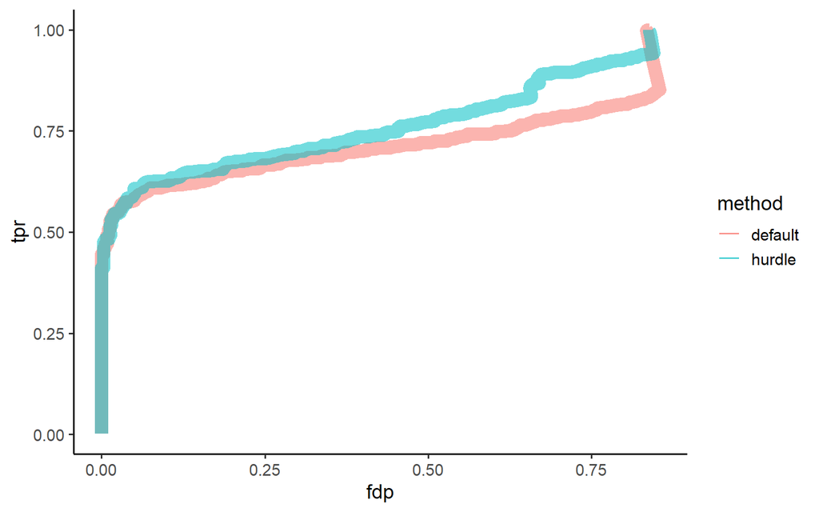

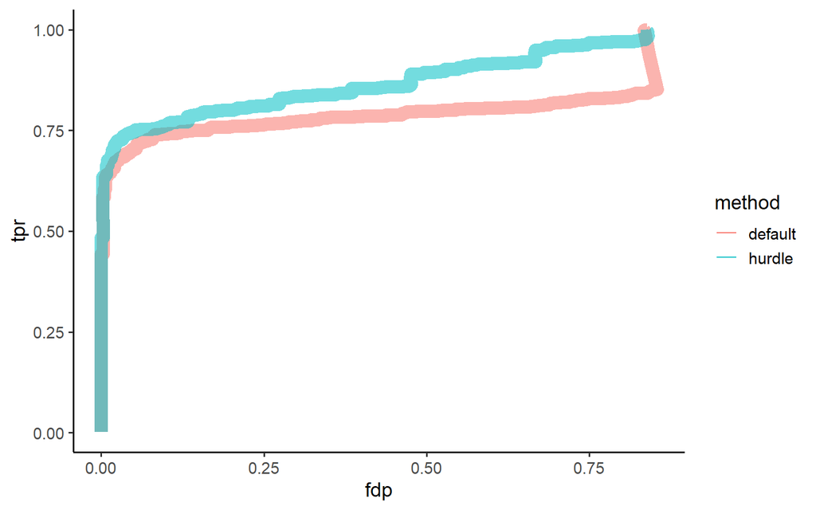

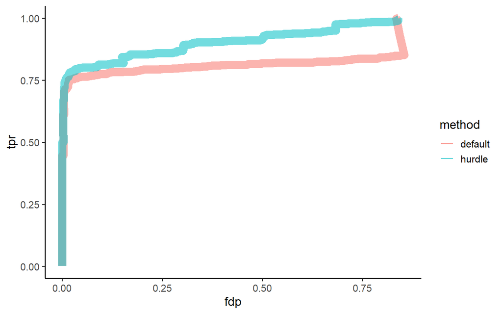

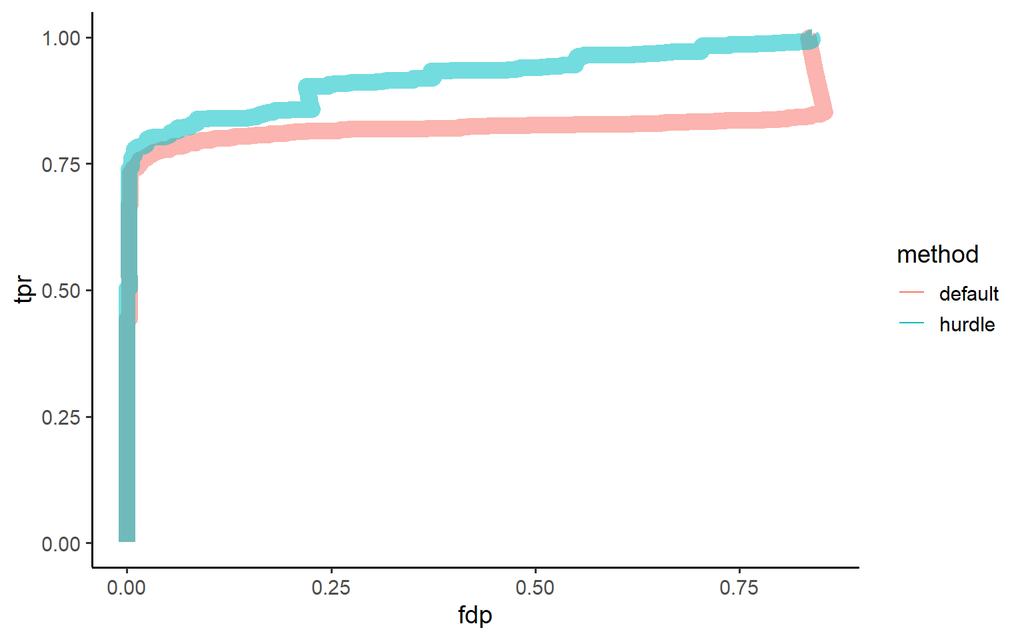

```
##
## $`conditionc - conditionb`
```

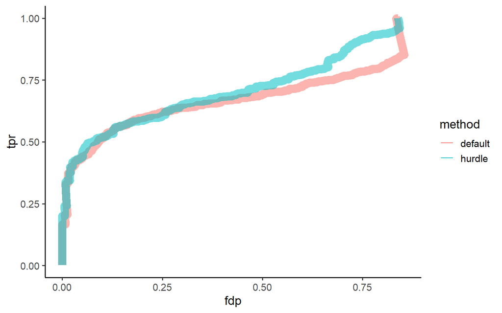

```
##
## $`conditiond - conditionb`
```

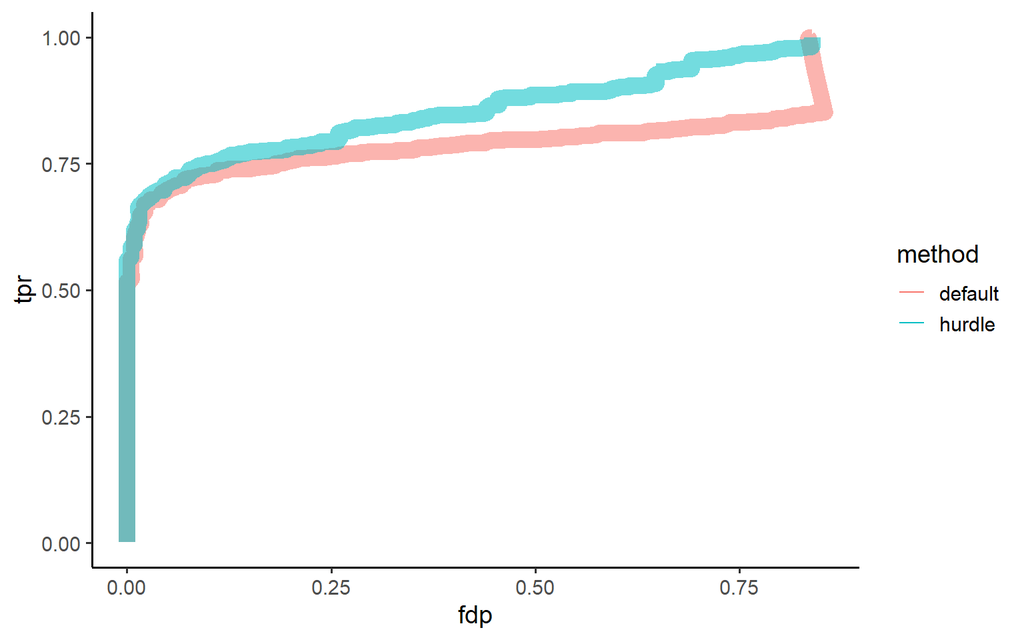

```
##
## $`conditione - conditionb`
```

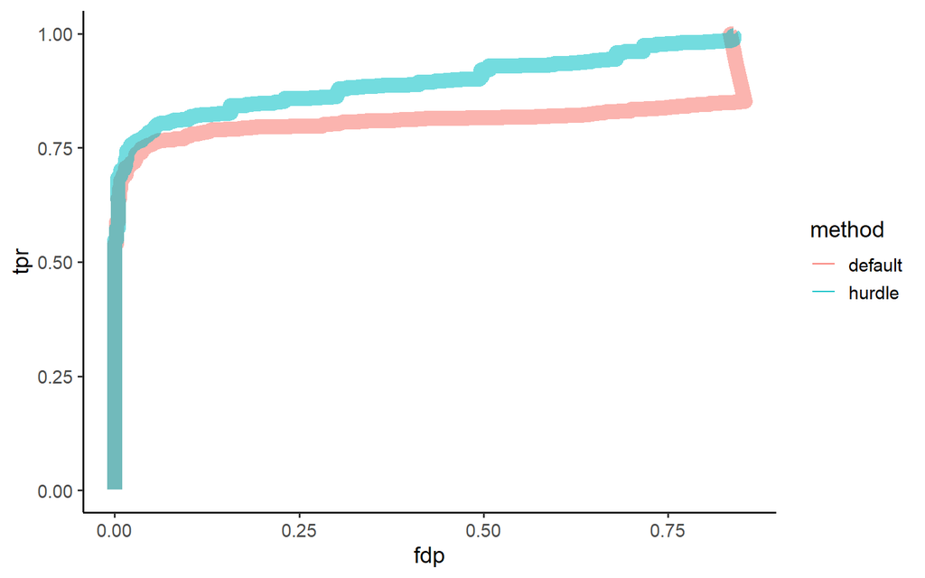

```
##
## $`conditiond - conditionc`
```

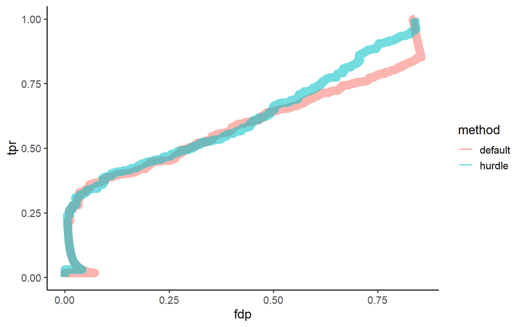

```
##
## $`conditione - conditionc`
```

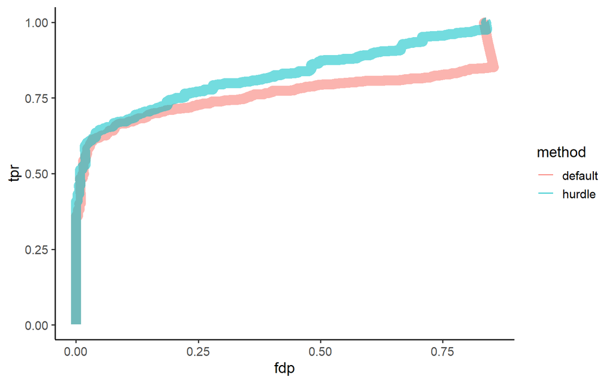

```
##
## $`conditione - conditiond`
```

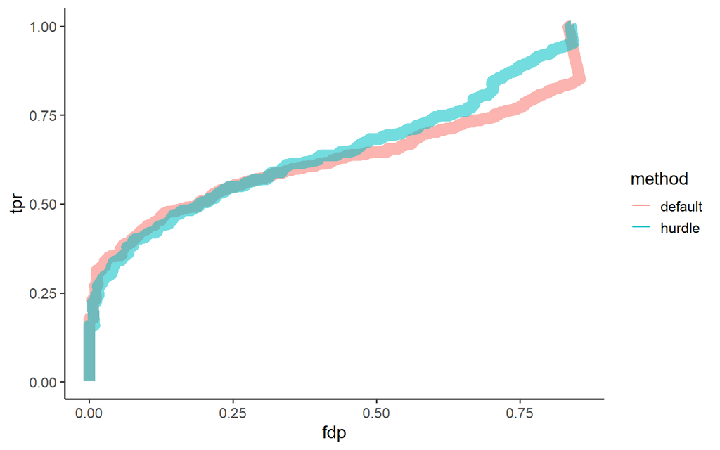

```r
tprFdpDefault <- list()
tprFdpHurdle <- list()
tprFdpPlots <- list()
for (i in colnames(L)) {
tprFdpDefault[[i]] <- tprFdp(rowData(pe[["protein"]])[[i]]$pval,
             rowData(pe[["protein"]])$accession$ecoli, rowData(pe[["protein"]])[[i]]$adjPval)
tprFdpHurdle[[i]] <- tprFdp(rowData(pe[["proteinCount"]])[[paste0("hurdle",i)]]$fisherPval,
             rowData(pe[["protein"]])$accession$ecoli, rowData(pe[["proteinCount"]])[[paste0("hurdle",i)]]$fisherAdjPval)
hlp <- rbind(cbind(tprFdpDefault[[i]], method = "default"), cbind(tprFdpHurdle[[i]], method = "hurdle"))
tprFdpPlots[[i]] <- hlp %>%
      ggplot(aes(x = fdp, y = tpr, color = method)) +
      geom_path(aes(alpha = 0.7, size = 4)) + theme_classic(base_size = 14) + guides(size = FALSE, alpha = FALSE)
      ggtitle(i)
}
tprFdpPlots
```

The performance of the hurdle method is better then of the default method, especially for the comparisons involving low concentrations.